# Practicing `tidytext` with song titles

```r
library(tidyverse)
library(acs)
library(tidytext)

set.seed(1234)
theme_set(theme_minimal())
```

# Download population data for U.S. states

> To import the data in-class, just use `read_csv("http://cfss.uchicago.edu/data/pop2016.csv")`

```r
# retrieve state populations in 2016 from Census Bureau ACS
library(tidycensus)
pop_df <- get_acs(geography = "state", year = 2016,
                    variables = c(population = "B01003_001")) %>%
  # remove moe and tidy the data frame
  select(-moe) %>%
  spread(variable, estimate) %>%
  # clean the data to match with the structure of the lyrics data
  rename(state_name = NAME) %>%
  mutate(state_name = str_to_lower(state_name)) %>%
  filter(state_name != "Puerto Rico") %>%
  write_csv("data/pop2016.csv")
# do these results make sense?
pop_df %>%
  arrange(desc(population)) %>%
  top_n(10)
```

```
## # A tibble: 10 x 3
##    GEOID state_name     population
##    <chr> <chr>               <dbl>
##  1 06    california       38654206
##  2 48    texas            26956435
##  3 12    florida          19934451
##  4 36    new york         19697457
##  5 17    illinois         12851684
##  6 42    pennsylvania     12783977
##  7 39    ohio             11586941
##  8 13    georgia          10099320
##  9 37    north carolina    9940828
## 10 26    michigan          9909600
```

# Retrieve song lyrics

> To import the data in-class, just use `read_csv("http://cfss.uchicago.edu/data/billboard_lyrics_1964-2015.csv")`

Next we need to retrieve the song lyrics for all our songs. [Kaylin Walker](http://kaylinwalker.com/50-years-of-pop-music/) provides a [GitHub repo with the necessary files.](https://github.com/walkerkq/musiclyrics)

```r
song_lyrics <- read_csv("data/billboard_lyrics_1964-2015.csv")
glimpse(song_lyrics)
```

```
## Observations: 5,100
## Variables: 6
## $ Rank   <int> 1, 2, 3, 4, 5, 6, 7, 8, 9, 10, 11, 12, 13, 14, 15, 16, ...
## $ Song   <chr> "wooly bully", "i cant help myself sugar pie honey bunc...
## $ Artist <chr> "sam the sham and the pharaohs", "four tops", "the roll...
## $ Year   <int> 1965, 1965, 1965, 1965, 1965, 1965, 1965, 1965, 1965, 1...
## $ Lyrics <chr> "sam the sham miscellaneous wooly bully wooly bully sam...
## $ Source <int> 3, 1, 1, 1, 1, 1, 3, 5, 1, 3, 3, 1, 3, 1, 3, 3, 3, 3, 1...
```

# Find and visualize the state names in the song lyrics

Now your work begins!

### Use `tidytext` to create a data frame with one row for each token in each song

Hint: To search for matching state names, this data frame should include both **unigrams** and **bi-grams**.

**Click for the solution**

```r
tidy_lyrics <- bind_rows(song_lyrics %>%
                           unnest_tokens(output = state_name,
                                         input = Lyrics),
                         song_lyrics %>%
                           unnest_tokens(output = state_name,
                                         input = Lyrics,
                                         token = "ngrams", n = 2))
tidy_lyrics
```

```
## # A tibble: 3,201,465 x 6
##     Rank Song        Artist                       Year Source state_name
##    <int> <chr>       <chr>                       <int>  <int> <chr>
##  1     1 wooly bully sam the sham and the phara…  1965      3 sam
##  2     1 wooly bully sam the sham and the phara…  1965      3 the
##  3     1 wooly bully sam the sham and the phara…  1965      3 sham
##  4     1 wooly bully sam the sham and the phara…  1965      3 miscellaneo…
##  5     1 wooly bully sam the sham and the phara…  1965      3 wooly
##  6     1 wooly bully sam the sham and the phara…  1965      3 bully
##  7     1 wooly bully sam the sham and the phara…  1965      3 wooly
##  8     1 wooly bully sam the sham and the phara…  1965      3 bully
##  9     1 wooly bully sam the sham and the phara…  1965      3 sam
## 10     1 wooly bully sam the sham and the phara…  1965      3 the
## # ... with 3,201,455 more rows
```

The variable `state_name` in this data frame contains all the possible words and bigrams that might be state names in all the lyrics.

### Find all the state names occurring in the song lyrics

First create a data frame that meets this criteria, then save a new data frame that only includes one observation for each matching song. That is, if the song is [“New York, New York”](https://www.youtube.com/watch?v=btFfXgUdIzY), there should only be one row in the resulting table for that song.

**Click for the solution**

```r
inner_join(tidy_lyrics, pop_df)
```

```
## # A tibble: 526 x 8
##     Rank Song          Artist      Year Source state_name GEOID population
##    <int> <chr>         <chr>      <int>  <int> <chr>      <chr>      <dbl>
##  1    12 king of the … roger mil…  1965      1 maine      23       1329923
##  2    29 eve of destr… barry mcg…  1965      1 alabama    01       4841164
##  3    49 california g… the beach…  1965      3 california 06      38654206
##  4    49 california g… the beach…  1965      3 california 06      38654206
##  5    49 california g… the beach…  1965      3 california 06      38654206
##  6    49 california g… the beach…  1965      3 california 06      38654206
##  7    49 california g… the beach…  1965      3 california 06      38654206
##  8    49 california g… the beach…  1965      3 california 06      38654206
##  9    49 california g… the beach…  1965      3 california 06      38654206
## 10    49 california g… the beach…  1965      3 california 06      38654206
## # ... with 516 more rows
```

Let’s only count each state once per song that it is mentioned in.

```r
tidy_lyrics <- inner_join(tidy_lyrics, pop_df) %>%
  distinct(Rank, Song, Artist, Year, state_name, .keep_all = TRUE)
tidy_lyrics
```

```
## # A tibble: 253 x 8
##     Rank Song        Artist        Year Source state_name GEOID population
##    <int> <chr>       <chr>        <int>  <int> <chr>      <chr>      <dbl>
##  1    12 king of th… roger miller  1965      1 maine      23       1329923
##  2    29 eve of des… barry mcgui…  1965      1 alabama    01       4841164
##  3    49 california… the beach b…  1965      3 california 06      38654206
##  4    10 california… the mamas  …  1966      3 california 06      38654206
##  5    77 message to… dionne warw…  1966      1 kentucky   21       4411989
##  6    61 california… lesley gore   1967      1 california 06      38654206
##  7     4 sittin on … otis redding  1968      1 georgia    13      10099320
##  8    10 tighten up  archie bell…  1968      3 texas      48      26956435
##  9    25 get back    the beatles…  1969      3 arizona    04       6728577
## 10    25 get back    the beatles…  1969      3 california 06      38654206
## # ... with 243 more rows
```

### Calculate the frequency for each state’s mention in a song and create a new column for the frequency adjusted by the state’s population

**Click for the solution**

```r
(state_counts <- tidy_lyrics %>%
   count(state_name) %>%
   arrange(desc(n)))
```

```
## # A tibble: 33 x 2
##    state_name      n
##    <chr>       <int>
##  1 new york       64
##  2 california     34
##  3 georgia        22
##  4 tennessee      14
##  5 texas          14
##  6 alabama        12
##  7 mississippi    10
##  8 kentucky        7
##  9 hawaii          6
## 10 illinois        6
## # ... with 23 more rows
```

```r
pop_df <- pop_df %>%
  left_join(state_counts) %>%
  mutate(rate = n / population * 1e6)
pop_df %>%
  arrange(desc(rate)) %>%
  top_n(10)
```

```
## # A tibble: 10 x 5
##    GEOID state_name  population     n  rate
##    <chr> <chr>            <dbl> <int> <dbl>
##  1 15    hawaii         1413673     6  4.24
##  2 28    mississippi    2989192    10  3.35
##  3 36    new york      19697457    64  3.25
##  4 01    alabama        4841164    12  2.48
##  5 23    maine          1329923     3  2.26
##  6 13    georgia       10099320    22  2.18
##  7 47    tennessee      6548009    14  2.14
##  8 30    montana        1023391     2  1.95
##  9 31    nebraska       1881259     3  1.59
## 10 21    kentucky       4411989     7  1.59
```

### Make a choropleth map for both the raw frequency counts and relative frequency counts

The [`statebins` package](https://github.com/hrbrmstr/statebins) is a nifty shortcut for making basic U.S. cartogram maps.

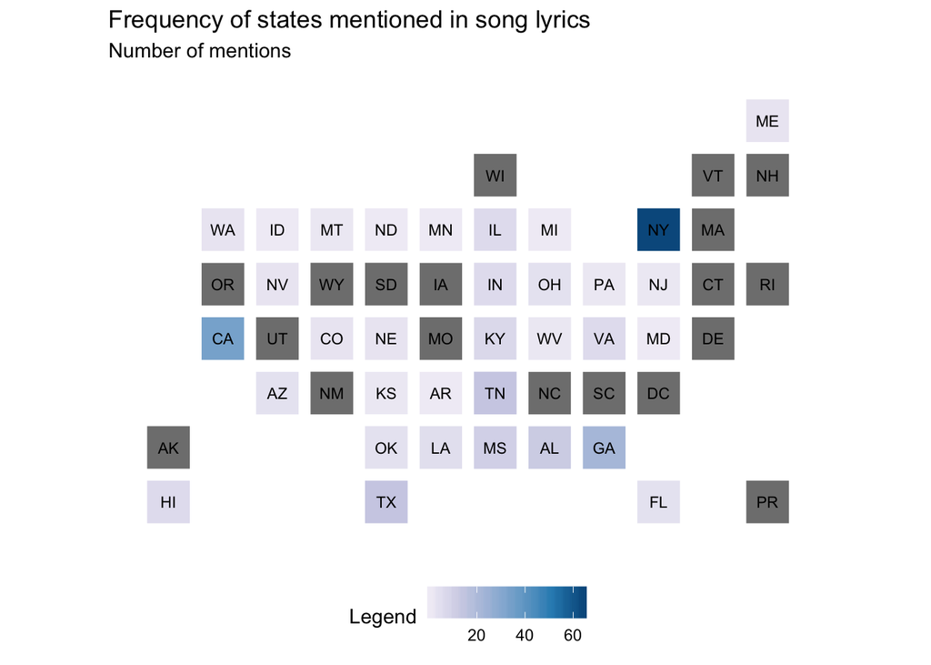

```r
library(statebins)

pop_df %>%
  mutate(state_name = stringr::str_to_title(state_name),
         state_name = if_else(state_name == "District Of Columbia",
                              "District of Columbia", state_name)) %>%
  statebins_continuous(state_col = "state_name", value_col = "n") +
  labs(title = "Frequency of states mentioned in song lyrics",
       subtitle = "Number of mentions") +
  theme(legend.position = "bottom")
```

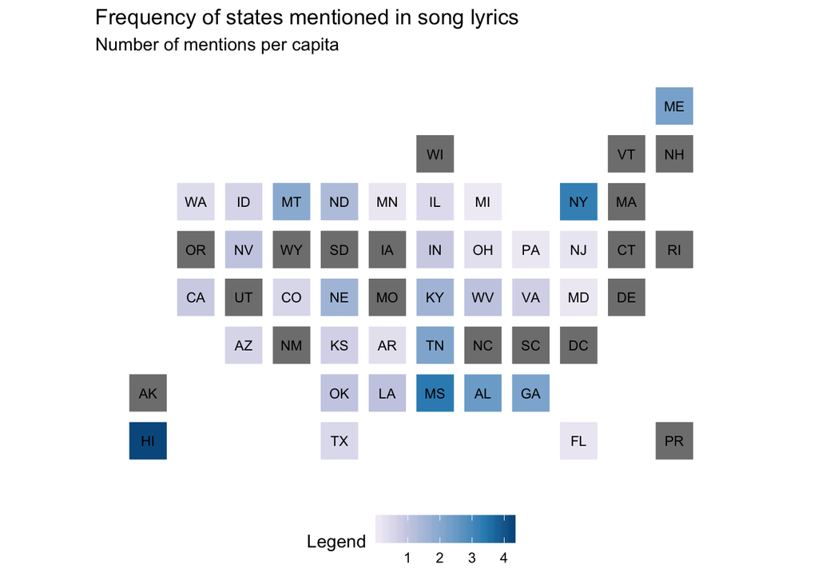

```r
pop_df %>%
  mutate(state_name = stringr::str_to_title(state_name),
         state_name = if_else(state_name == "District Of Columbia",
                              "District of Columbia", state_name)) %>%
  statebins_continuous(state_col = "state_name", value_col = "rate") +
  labs(title = "Frequency of states mentioned in song lyrics",
       subtitle = "Number of mentions per capita") +
  theme(legend.position = "bottom")
```

# Acknowledgments

- This page is derived in part from [SONG LYRICS ACROSS THE UNITED STATES](https://juliasilge.com/blog/song-lyrics-across/) and licensed under a [Creative Commons Attribution-ShareAlike 4.0 International License](https://creativecommons.org/licenses/by-sa/4.0/).

```
##  setting  value
##  version  R version 3.5.1 (2018-07-02)
##  system   x86_64, darwin15.6.0
##  ui       X11
##  language (EN)
##  collate  en_US.UTF-8
##  tz       America/Chicago
##  date     2019-01-02
```

```
## Packages -----------------------------------------------------------------
```

[output not shown]

[output cut: 18 more lines]

[output not shown]

[^1]: For instance, California has a lot more people than Rhode Island so it makes sense that California would be mentioned more often in popular songs. But per capita, are these mentions different?

This work is licensed under the [CC BY-NC 4.0 Creative Commons License](http://creativecommons.org/licenses/by-nc/4.0/).